# Using SpatialKWD package

Julien Jamme

2023-04-13

## Objectives

- Learn how to use the functions within the `SpatialKWD` package
- How the KWD measure reacts to different kinds of compared maps
- How different from a standard measure is the KWD measure when comparing maps ?
- Learn about the time computation : How big can be the maps to compare them in a realistic time ?
- L = 2/L=3/L=10 => how does this parameter influence the quality of the measure and the computation’s time ?

```r
if(! "SpatialKWD" %in% installed.packages()[,1]) install.packages("SpatialKWD")
library(ggplot2)
library(purrr)
library(dplyr)
library(SpatialKWD)
library(raster)
source("R/functions.R", encoding = "UTF-8")
```

```r
shift_weight <- function(coordinates, weights, type = "horizontal", shift = 1){
  require(dplyr)

  data <- cbind(coordinates[,1:2], weights[,1]) %>%
    as_tibble()
  names(data) <- paste0("V",1:3)
  shifted <- data %>% {
    if(type == "horizontal") arrange(.,V2) %>% group_by(V2) else arrange(.,V1) %>% group_by(V1)} %>%
    mutate(V4 = lag(V3, default = 0)) %>% {
      if(type != "horizontal") arrange(.,V2,V1) else .} %>%
    pull(V4)
  return(cbind(weights, shifted))
}
```

## `CompareOneToOne()`

This function lets compare a distribution with one another.

### Example of the documentation

```r
set.seed(4081789)
# Random coordinates
N = 90
Xs <- as.integer(runif(N, 0, 31))
Ys <- as.integer(runif(N, 0, 31))
coordinates <- matrix(c(Xs, Ys), ncol=2, nrow=N)
# Random weights
test1 <- matrix(runif(2*N, 0, 1), ncol=2, nrow=N)
```

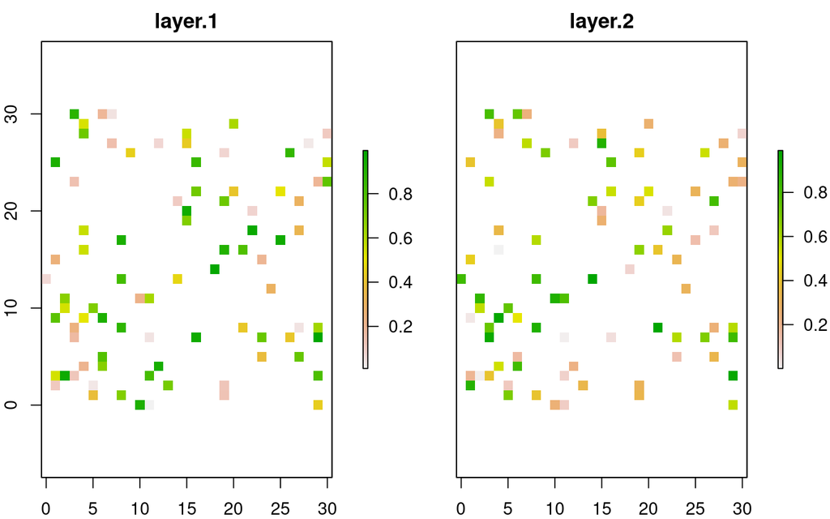

```r
matrix_to_maps(coordinates, test1) |> plot()
```

```r
d_OTO <- compareOneToOne(
  coordinates, Weights=test1,
  L = 2,
  method="approx",
  recode=TRUE,
)
```

```
## CompareOneToOne, Solution method: APPROX
## INFO: Recoding the input coordinates to consecutive integers.
## INFO: change <timelimit> to 14400.000000
## INFO: change <verbosity> to silent
## INFO: change <opt_tolerance> to 0.000001
```

```r
euclid(test1)
```

```
## [1] 0.4234737
```

```r
str(d_OTO)
```

```
## List of 6
##  $ distance  : num 1.87
##  $ runtime   : num 2.33
##  $ iterations: int 2578
##  $ nodes     : int 897
##  $ arcs      : int 1149
##  $ status    : chr "Optimal"
```

### Other simple examples

#### Parameters

```r
wid = 10
len = 10
N = wid * len

Xs <- 1:wid
Ys <- 1:len

coordinates <- expand.grid(Xs, Ys) |> as.matrix()
```

#### Random noise

```r
set.seed(4081789)
weights <- matrix(runif(2*N, 0, 1), ncol=2, nrow=N)
```

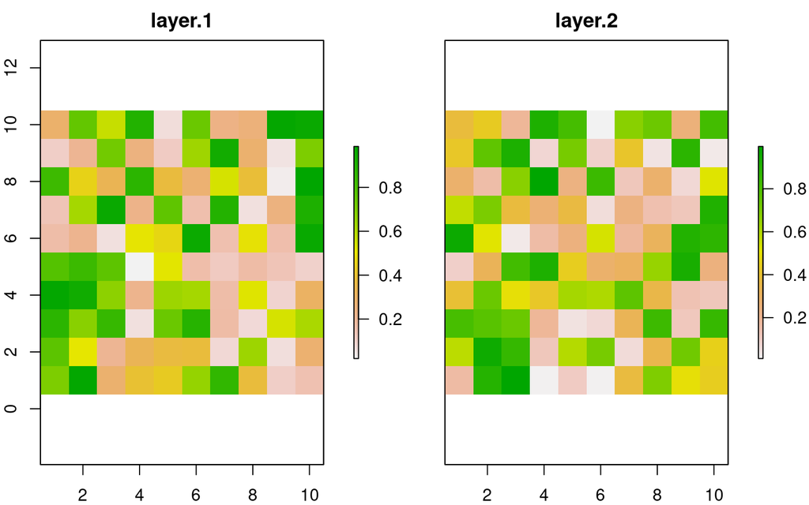

```r
matrix_to_maps(coordinates, weights) |> plot()
```

The `compare_distances` function computes the KW distance and its challengers at once. The KWD is computed with `SpatialKWD::compareOneToMany()` and with the following main parameters : `L = 3`, `method = "approx"`, `recode = TRUE`.

```r
(distances_rn <- compare_distances(coordinates, weights))
```

```
## CompareOneToMany, Solution method: APPROX
## INFO: Recoding the input coordinates to consecutive integers.
## INFO: change <timelimit> to 14400.000000
## INFO: change <verbosity> to silent
## INFO: change <opt_tolerance> to 0.000001
```

```
## # A tibble: 4 × 3
##   distance  map     val
##   <chr>     <chr> <dbl>
## 1 kwd       V2    0.572
## 2 Hellinger V2    0.362
## 3 euclid    V2    0.422
## 4 aard      V2    1.94
```

#### Two identical maps

```r
weights <- matrix(runif(N, 0, 1), ncol=1, nrow=N)
weights <- cbind(weights, weights)
```

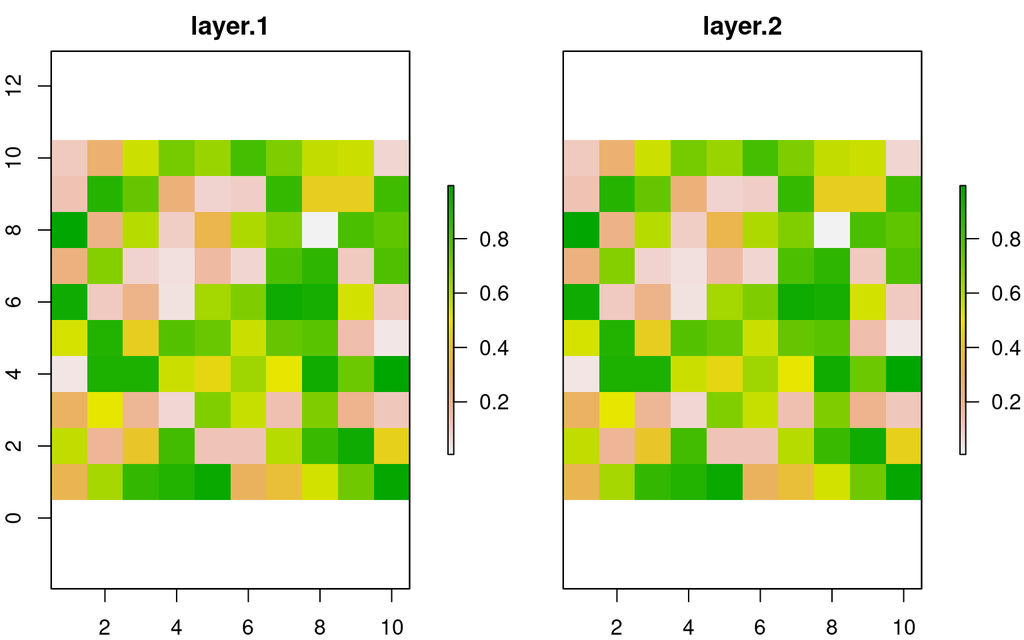

```r
matrix_to_maps(coordinates, weights) |> plot()
```

```r
(distances_id <- compare_distances(coordinates, weights))
```

```
## CompareOneToMany, Solution method: APPROX
## INFO: Recoding the input coordinates to consecutive integers.
## INFO: change <timelimit> to 14400.000000
## INFO: change <verbosity> to silent
## INFO: change <opt_tolerance> to 0.000001
```

```
## # A tibble: 4 × 3
##   distance  map     val
##   <chr>     <chr> <dbl>
## 1 kwd       V2        0
## 2 Hellinger V2        0
## 3 euclid    V2        0
## 4 aard      V2        0
```

#### Two horizontal shifted maps

```r
set.seed(4081789)
weights <- matrix(runif(N, 0, 1), ncol=1, nrow=N)
colnames(weights) = "orig"
weights <- shift_weight(coordinates, weights)
```

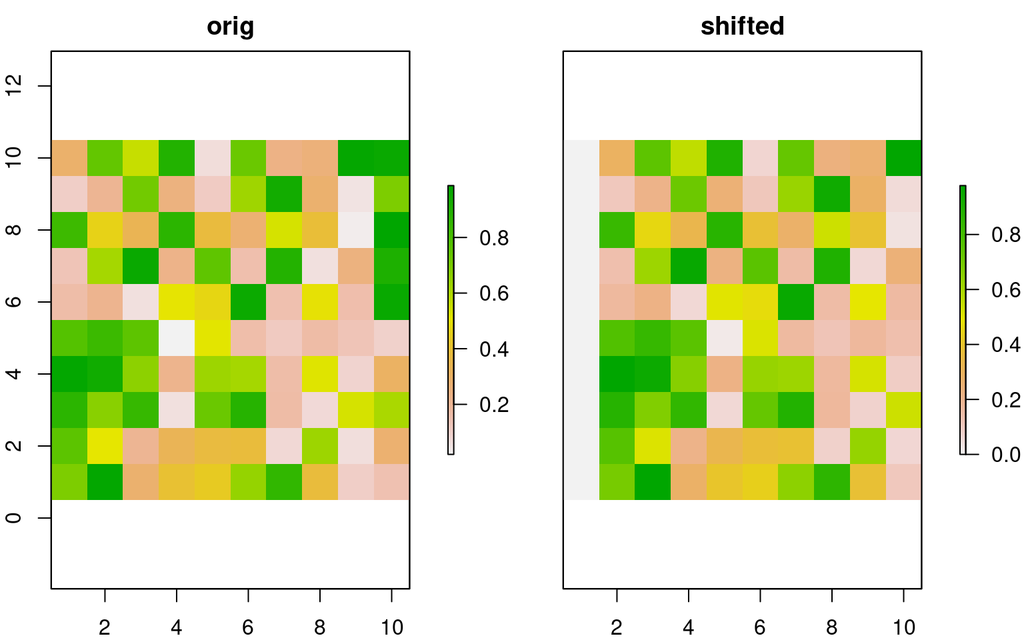

```r
matrix_to_maps(coordinates, weights) |> plot()
```

```r
(distances_sh <- compare_distances(coordinates, weights))
```

```
## CompareOneToMany, Solution method: APPROX
## INFO: Recoding the input coordinates to consecutive integers.
## INFO: change <timelimit> to 14400.000000
## INFO: change <verbosity> to silent
## INFO: change <opt_tolerance> to 0.000001
```

```
## # A tibble: 4 × 3
##   distance  map       val
##   <chr>     <chr>   <dbl>
## 1 kwd       shifted 0.695
## 2 Hellinger shifted 0.440
## 3 euclid    shifted 0.459
## 4 aard      shifted 1.97
```

#### Two vertical shifted maps

```r
set.seed(4081789)
weights <- matrix(runif(N, 0, 1), ncol=1, nrow=N)
weights <- shift_weight(coordinates, weights, type = "vertical")
```

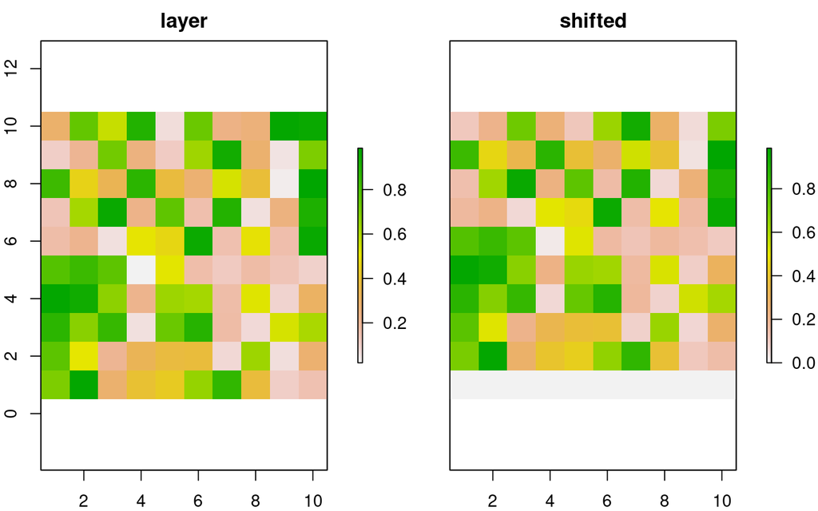

```r
matrix_to_maps(coordinates, weights) |> plot()
```

```r
(distances_sv <- compare_distances(coordinates, weights))
```

```
## CompareOneToMany, Solution method: APPROX
## INFO: Recoding the input coordinates to consecutive integers.
## INFO: change <timelimit> to 14400.000000
## INFO: change <verbosity> to silent
## INFO: change <opt_tolerance> to 0.000001
```

```
## # A tibble: 4 × 3
##   distance  map       val
##   <chr>     <chr>   <dbl>
## 1 kwd       shifted 0.604
## 2 Hellinger shifted 0.405
## 3 euclid    shifted 0.425
## 4 aard      shifted 1.44
```

#### Chessboard maps

```r
vs <- c(0.25,0.75)
b1 <- matrix(vs[1], ncol = len/2, nrow = wid/2)
b2 <- matrix(vs[2], ncol = len/2, nrow = wid/2)
w1 <- rbind(cbind(b1,b2),cbind(b2,b1))
w2 <- rbind(cbind(b2,b1),cbind(b1,b2))

weights <- cbind(
  from_matrix_to_column(w1),
  from_matrix_to_column(w2)
)
```

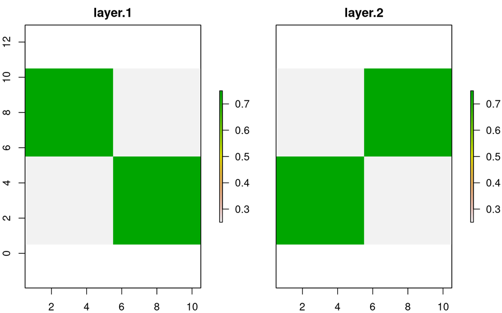

```r
matrix_to_maps(coordinates, weights) |> plot()
```

```r
(distances_ch <- compare_distances(coordinates, weights))
```

```
## CompareOneToMany, Solution method: APPROX
## INFO: Recoding the input coordinates to consecutive integers.
## INFO: change <timelimit> to 14400.000000
## INFO: change <verbosity> to silent
## INFO: change <opt_tolerance> to 0.000001
```

```
## # A tibble: 4 × 3
##   distance  map     val
##   <chr>     <chr> <dbl>
## 1 kwd       V2    1.7
## 2 Hellinger V2    0.366
## 3 euclid    V2    0.5
## 4 aard      V2    1.33
```

#### Chessboard maps 2

```r
vs <- c(0.25,0.75)
b1 <- matrix(vs[1], ncol = 1, nrow = 1)
b2 <- matrix(vs[2], ncol = 1, nrow = 1)

w1 <- matrix(rep(c(b1, b2), 50), nrow=9, ncol=9, byrow = TRUE)
w2 <- matrix(rep(c(b2, b1), 50), nrow=9, ncol=9, byrow = TRUE)
weights <- cbind(
  from_matrix_to_column(w1),
  from_matrix_to_column(w2)
)

coordinates <- as.matrix(expand.grid(X=1:9, Y=1:9))
```

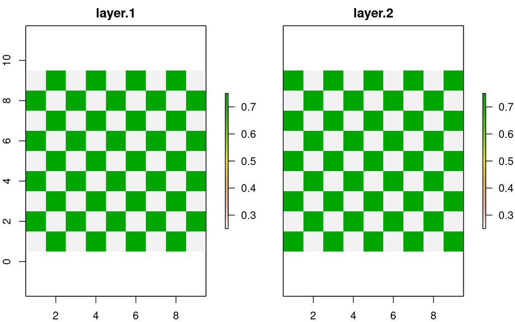

```r
matrix_to_maps(coordinates, weights) |> plot()
```

```r
(distances_ch2 <- compare_distances(coordinates, weights))
```

```
## CompareOneToMany, Solution method: APPROX
## INFO: Recoding the input coordinates to consecutive integers.
## INFO: change <timelimit> to 14400.000000
## INFO: change <verbosity> to silent
## INFO: change <opt_tolerance> to 0.000001
```

```
## # A tibble: 4 × 3
##   distance  map     val
##   <chr>     <chr> <dbl>
## 1 kwd       V2    0.500
## 2 Hellinger V2    0.366
## 3 euclid    V2    0.5
## 4 aard      V2    1.34
```

## Sensitivity to NA/empty values

```r
vs <- c(NA,0.75)
b1 <- matrix(vs[1], ncol = 1, nrow = 1)
b2 <- matrix(vs[2], ncol = 1, nrow = 1)

w1 <- matrix(rep(c(b1, b2), 50), nrow=9, ncol=9, byrow = TRUE)
w2 <- matrix(rep(c(b2, b1), 50), nrow=9, ncol=9, byrow = TRUE)
weights <- cbind(
  from_matrix_to_column(w1),
  from_matrix_to_column(w2)
)

coordinates <- as.matrix(expand.grid(X=1:9, Y=1:9))
```

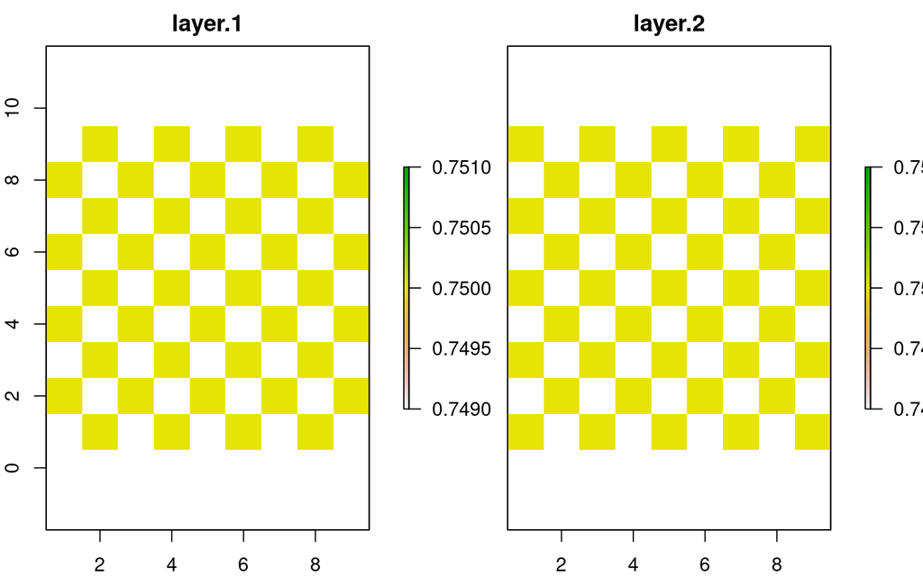

```r
matrix_to_maps(coordinates, weights) |> plot()
```

```r
(distances_na <- compare_distances(coordinates, weights))
```

```
## CompareOneToMany, Solution method: APPROX
## INFO: Recoding the input coordinates to consecutive integers.
## INFO: change <timelimit> to 14400.000000
## INFO: change <verbosity> to silent
## INFO: change <opt_tolerance> to 0.000001
```

```
## # A tibble: 4 × 3
##   distance  map     val
##   <chr>     <chr> <dbl>
## 1 kwd       V2        0
## 2 Hellinger V2       NA
## 3 euclid    V2       NA
## 4 aard      V2       NA
```

Distance is null. The presence of NA values seems to perturb the computation of the distance.

### NA to zeros

```r
weights[is.na(weights)] <- 0
```

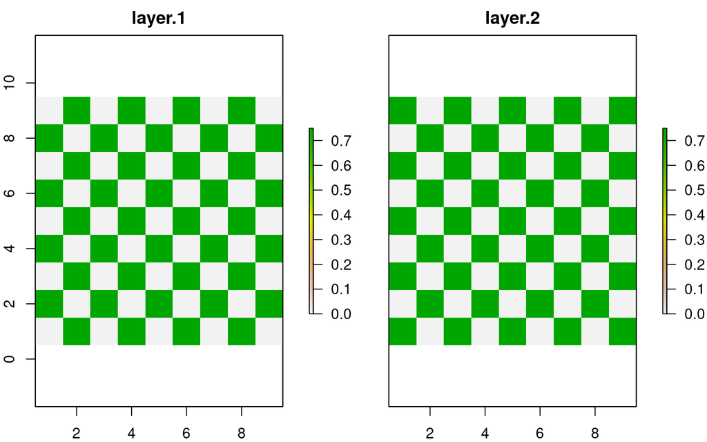

```r
matrix_to_maps(coordinates, weights) |> plot()
```

```r
(distances_zeros <- compare_distances(coordinates, weights))
```

```
## CompareOneToMany, Solution method: APPROX
## INFO: Recoding the input coordinates to consecutive integers.
## INFO: change <timelimit> to 14400.000000
## INFO: change <verbosity> to silent
## INFO: change <opt_tolerance> to 0.000001
```

```
## # A tibble: 4 × 3
##   distance  map     val
##   <chr>     <chr> <dbl>
## 1 kwd       V2     1.00
## 2 Hellinger V2     1
## 3 euclid    V2     0.75
## 4 aard      V2     1
```

## Work on autocorrelated data: the Meuse data

```r
data(meuse.grid, package = "sp")
dim(meuse.grid)
```

```
## [1] 3103    7
```

### Sensitivity to injection of noise in the data

```r
set.seed(4081789)
coordinates <- as.matrix(meuse.grid[,1:2])
sds <- c(0,0.001,0.01,0.1,0.5,1)
weights <- purrr::map(
  sds,
  function(sd)  meuse.grid[,"dist"] + 10 + rnorm(nrow(meuse.grid), 0, sd)
) %>% purrr::reduce(cbind)
colnames(weights) <- paste0("sd=",sds)
```

Remark: the +10 operation is to ensure the values remain positive.

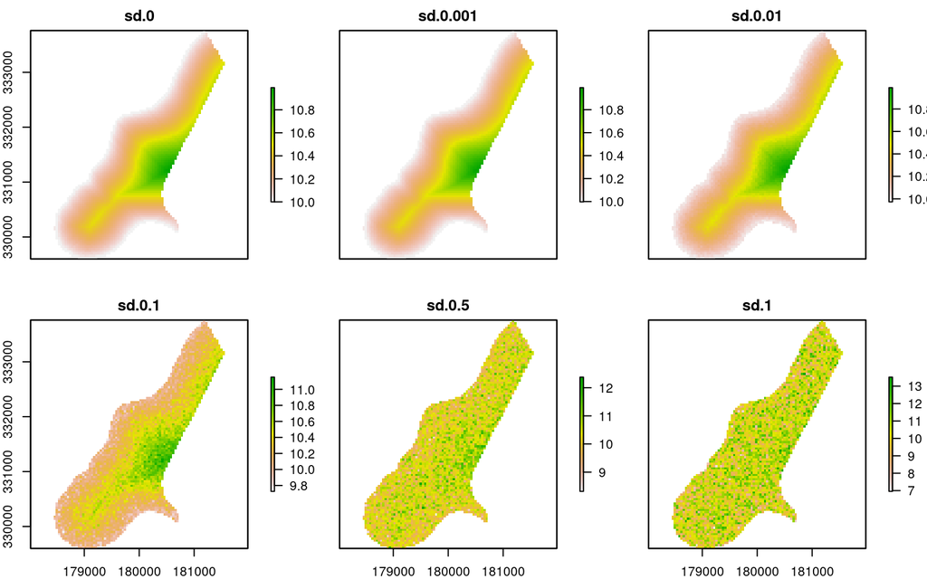

```r
matrix_to_maps(coordinates, weights) |> plot()
```

```r
(distances_autocorr <- compare_distances(coordinates, weights))
```

```
## CompareOneToMany, Solution method: APPROX
## WARNING: the Xs input coordinates are not consecutives integers.
## WARNING: the Ys input coordinates are not consecutives integers.
## INFO: Recoding the input coordinates to consecutive integers.
## INFO: change <timelimit> to 14400.000000
## INFO: change <verbosity> to silent
## INFO: change <opt_tolerance> to 0.000001
```

```
## # A tibble: 20 × 3
##    distance  map            val
##    <chr>     <chr>        <dbl>
##  1 kwd       sd=0.001 0.0000878
##  2 kwd       sd=0.01  0.000850
##  3 kwd       sd=0.1   0.00802
##  4 kwd       sd=0.5   0.0351
##  5 kwd       sd=1     0.0846
##  6 Hellinger sd=0.001 0.0000346
##  7 Hellinger sd=0.01  0.000348
##  8 Hellinger sd=0.1   0.00338
##  9 Hellinger sd=0.5   0.0171
## 10 Hellinger sd=1     0.0344
## 11 euclid    sd=0.001 0.00101
## 12 euclid    sd=0.01  0.0101
## 13 euclid    sd=0.1   0.0983
## 14 euclid    sd=0.5   0.498
## 15 euclid    sd=1     0.998
## 16 aard      sd=0.001 0.0000788
## 17 aard      sd=0.01  0.000788
## 18 aard      sd=0.1   0.00755
## 19 aard      sd=0.5   0.0382
## 20 aard      sd=1     0.0771
```

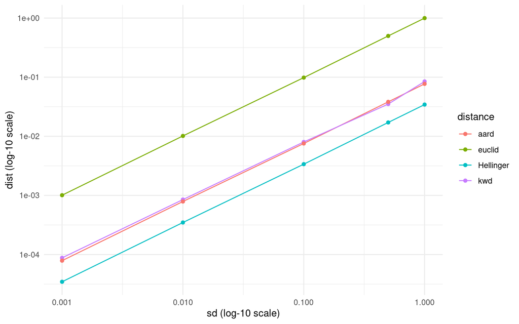

```r
distances_autocorr %>%
  mutate(sd = as.numeric(gsub("sd=","",map))) %>%
  ggplot(aes(x=sd, y = val, color = distance)) +
  geom_line() +
  geom_point() +
  scale_x_log10("sd (log-10 scale)") +
  scale_y_log10("dist (log-10 scale)") +
  theme_minimal()
```

### Sensitivity to the magnitude

We compare two maps different only on the magnitude of the cell values: map2 is like map1 + A or like map1*B.

```r
summary(meuse.grid[,"dist"])
```

```
##    Min. 1st Qu.  Median    Mean 3rd Qu.    Max.
##  0.0000  0.1193  0.2715  0.2971  0.4402  0.9926
```

```r
mean_dist <- mean(meuse.grid[,"dist"])
```

#### translation of the distribution

Map2 = Map1 + A

```r
coordinates <- as.matrix(meuse.grid[,1:2])
weights <- purrr::map(
  c(0,1,2,10,100,1000),
  function(a)  meuse.grid[,"dist"] + a*mean_dist
) %>% purrr::reduce(cbind)
colnames(weights) <- paste0("a=",c(0,1,2,10,100,1000))
```

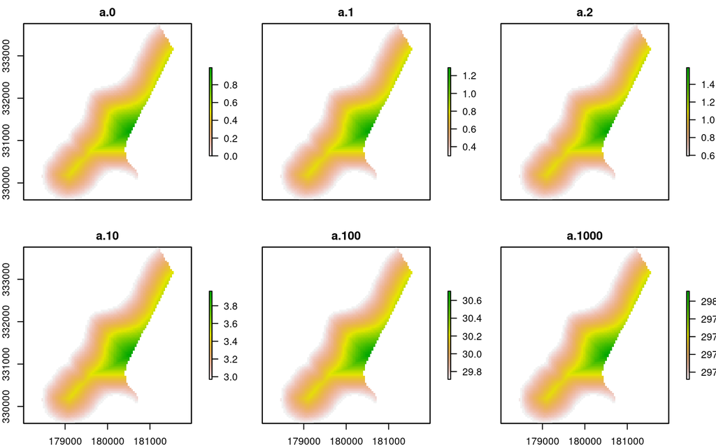

```r
matrix_to_maps(coordinates, weights) |> plot()
```

```r
(distances_trans <- compare_distances(coordinates, weights))
```

```
## CompareOneToMany, Solution method: APPROX
## WARNING: the Xs input coordinates are not consecutives integers.
## WARNING: the Ys input coordinates are not consecutives integers.
## INFO: Recoding the input coordinates to consecutive integers.
## INFO: change <timelimit> to 14400.000000
## INFO: change <verbosity> to silent
## INFO: change <opt_tolerance> to 0.000001
```

```
## # A tibble: 20 × 3
##    distance  map         val
##    <chr>     <chr>     <dbl>
##  1 kwd       a=1       3.45
##  2 kwd       a=2       4.60
##  3 kwd       a=10      6.27
##  4 kwd       a=100     6.83
##  5 kwd       a=1000    6.89
##  6 Hellinger a=1       0.179
##  7 Hellinger a=2       0.221
##  8 Hellinger a=10      0.279
##  9 Hellinger a=100     0.299
## 10 Hellinger a=1000    0.301
## 11 euclid    a=1       0.297
## 12 euclid    a=2       0.594
## 13 euclid    a=10      2.97
## 14 euclid    a=100    29.7
## 15 euclid    a=1000  297.
## 16 aard      a=1       5.53
## 17 aard      a=2      11.1
## 18 aard      a=10     55.3
## 19 aard      a=100   553.
## 20 aard      a=1000 5526.
```

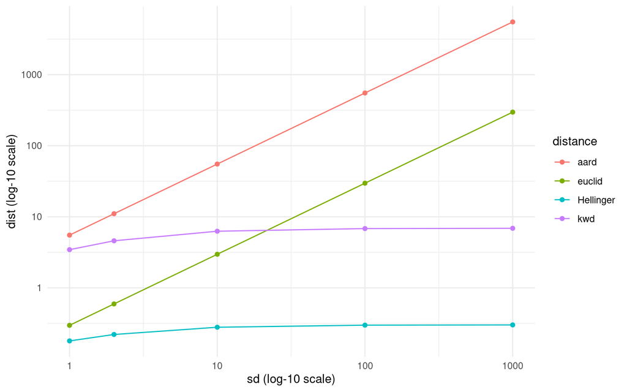

```r
distances_trans %>%
  mutate(a = as.numeric(gsub("a=","",map))) %>%
  ggplot(aes(x=a, y = val, color = distance)) +
  geom_line() +
  geom_point() +
  scale_x_log10("sd (log-10 scale)") +
  scale_y_log10("dist (log-10 scale)") +
  theme_minimal()
```

#### Homothetic transformation of the distribution

Map2 = Map1 * B

```r
coordinates <- as.matrix(meuse.grid[,1:2])
weights <- purrr::map(
  c(1/mean_dist,1,2,10,100,1000),
  function(a)  meuse.grid[,"dist"] * a*mean_dist
) %>% purrr::reduce(cbind)
colnames(weights) <- paste0("a=", c(0,1,2,10,100,1000),"*mean")
```

```r
(distances_hom <- compare_distances(coordinates, weights))
```

```
## CompareOneToMany, Solution method: APPROX
## WARNING: the Xs input coordinates are not consecutives integers.
## WARNING: the Ys input coordinates are not consecutives integers.
## INFO: Recoding the input coordinates to consecutive integers.
## INFO: change <timelimit> to 14400.000000
## INFO: change <verbosity> to silent
## INFO: change <opt_tolerance> to 0.000001
```

```
## # A tibble: 20 × 3
##    distance  map              val
##    <chr>     <chr>          <dbl>
##  1 kwd       a=1*mean    0
##  2 kwd       a=2*mean    0
##  3 kwd       a=10*mean   0
##  4 kwd       a=100*mean  0
##  5 kwd       a=1000*mean 0
##  6 Hellinger a=1*mean    5.60e-17
##  7 Hellinger a=2*mean    5.60e-17
##  8 Hellinger a=10*mean   7.56e-17
##  9 Hellinger a=100*mean  7.12e-17
## 10 Hellinger a=1000*mean 5.87e-17
## 11 euclid    a=1*mean    2.59e- 1
## 12 euclid    a=2*mean    1.50e- 1
## 13 euclid    a=10*mean   7.27e- 1
## 14 euclid    a=100*mean  1.06e+ 1
## 15 euclid    a=1000*mean 1.09e+ 2
## 16 aard      a=1*mean    7.03e- 1
## 17 aard      a=2*mean    4.06e- 1
## 18 aard      a=10*mean   1.97e+ 0
## 19 aard      a=100*mean  2.87e+ 1
## 20 aard      a=1000*mean 2.96e+ 2
```

## TODO

- test the effect of the L values
- compare different scales of the map